# Python for Data Analysis

# Tour de Python Level 2 ●○○○

- Python `stdlib`
- `import` syntax
- Python packages

## built-in Python

- Everything we've talked about so far is referred to as part of the Python "built-in"s
- Every Python session has access to everything we've learned no matter what
- The built-ins are general purpose building blocks: "primitive" data types (like strings, integers, dictionaries), control flow statements, basic operators, etc

## moving on (briefly) to the Python `stdlib`

- every Python installation also comes with special data types, operators, functions, and methods to address specific types of problems
  - ex. `datetime` for storing time data that are cognizant of year/month/day/timezone
- by default these are not loaded into each Python session, but instead have to be **imported**
- `stdlib` = "standard library"

## Python modules

```python
import math
```

- the list of modules already accessible to any vanilla Python installation because they are in the `stdlib` are listed online at https://docs.python.org/3/library/ ⇢
- importing a module makes its code definitions accessible in whatever environment they are being imported to

## Variants of import syntax and namespaces

- Python provides 3 styles of import syntax that affect the namespacing of the imported module and its members

```python
import math
math.ceil(5)
```

```
5
```

## Anatomy of import syntax 1

**if import syntax is:**

import module_name

**then call syntax is:**

module_name.member_name

```python
import math as m
m.ceil(5)
```

```
5
```

## Anatomy of import syntax 2

**if import syntax is:**

import module_name as alias

**then call syntax is:**

alias.member_name

```python
from math import ceil
ceil(5)
```

```
5
```

## Anatomy of import syntax 3

**if import syntax is:**

from module_name import member_name, ...

**then call syntax is:**

member_name

## `stdlib` greatest hits

- `datetime`
- `random.seed`, `random.random`
- `os.path.exists`, `os.path.join`, `os.path.abspath`
- `csv.reader`, `csv.DictReader`
- `csv.writer`
- `json.loads`, `json.dumps`

## Get your feet wet

In the Python interpreter, try using the 3 different styles of import syntax to import the following **functions**, and call them properly based on the type of import syntax you used. You will need to exit and re-enter your python session to clear your prior import syntax each time.

- `random.random`
- `os.getcwd`

## Going past the `stdlib`

- remember: the `stdlib` is maintained by the Python Software Foundation and comes with every installation of Python
- other members of the Python community write their own extensions to the Python built-ins called **packages**
  - usually they are even more specialized than modules in the `stdlib`

## Introducing our data analysis packages

- **Pandas**
  - used for processing tabular data
  - core data type is the `DataFrame`
  - port of R's DataFrame paradigm
- **Matplotlib**
  - used to generate charts such as histograms or box plots from Python data structures
  - port of MATLAB's charting functionalilty

## Installing python packages

- lucky you - you don't have to! For this class, since we used the Anaconda distribution of Python, the python packages we want to use are already installed!
  - the full list for your installation can be found at https://docs.anaconda.com/anaconda/packages/pkg-docs ⇢
- more generally: there are many ways to find and download community-supported Python extensions, but the most popular way is via a *package manager* that downloads from PyPI at https://pypi.python.org/pypi ⇢
  - popular *package managers* include `pip`, `pipenv`, and `conda`

# `pandas`

# Tour de Python Level 2 ○●○○

- `DataFrame`
- `Series`
- Python attributes
- `DataFrame` indexing
- Querying `DataFrame`s with boolean series

```python
import pandas as pd
```

```python
df = pd.read_csv("iris.csv")
```

```python
type(df)
```

```
pandas.core.frame.DataFrame
```

```python
df.head()
```

|  | Sepal Length | Sepal Width | Petal Length | Petal Width | Species |
| --- | --- | --- | --- | --- | --- |
| 0 | 5.1 | 3.5 | 1.4 | 0.2 | setosa |
| 1 | 4.9 | 3.0 | 1.4 | 0.2 | setosa |
| 2 | 4.7 | 3.2 | 1.3 | 0.2 | setosa |
| 3 | 4.6 | 3.1 | 1.5 | 0.2 | setosa |
| 4 | 5.0 | 3.6 | 1.4 | 0.2 | setosa |

```python
df.head(2)
```

|  | Sepal Length | Sepal Width | Petal Length | Petal Width | Species |
| --- | --- | --- | --- | --- | --- |
| 0 | 5.1 | 3.5 | 1.4 | 0.2 | setosa |
| 1 | 4.9 | 3.0 | 1.4 | 0.2 | setosa |

## The `pandas` dataframe

- a two dimensional data structure representing tabular data
- has *columns* and *rows*
- each column's data is of the same *data type*

## Creating a pandas dataframe

- use a convenience function against a file on disk
  - [`pd.read_csv`](https://pandas.pydata.org/pandas-docs/stable/generated/pandas.read_csv.html), for CSV data
  - [`pd.read_table`](https://pandas.pydata.org/pandas-docs/stable/generated/pandas.read_table.html), for general reading of tabular data, including `.tsv` files
  - [`pd.read_json`](https://pandas.pydata.org/pandas-docs/stable/generated/pandas.read_json.html) for JSON data
  - [`pd.read_excel`](https://pandas.pydata.org/pandas-docs/stable/generated/pandas.read_excel.html) for Excel files, particularly useful for excel files with many sheets
  - [`pd.read_html`](https://pandas.pydata.org/pandas-docs/stable/generated/pandas.read_html.html) for reading HTML `<table>`s

```python
df = pd.read_csv("iris.csv")
```

## Anatomy of a pandas dataframe convenience function

variable_name = pd.convenience_method(path_as_a_string)

- read_csv
- read_table
- read_json
- read_excel
- read_html

PS: Of course, remember that the path can be an absolute or relative path!

## Creating a pandas dataframe inline

- instantiate a `dataframe` instance directly, passing it a `data` parameter with something that can be cast into a dataframe shape
- the general format for something that can be cast to a dataframe shape takes a form like: `[[ row],[row],[row]]`

```python
df_direct = pd.DataFrame(data=[["a", 1, 5.0], ["b", 2, 10.0]])
```

```python
df_direct
```

|  | 0 | 1 | 2 |
| --- | --- | --- | --- |
| 0 | a | 1 | 5.0 |
| 1 | b | 2 | 10.0 |

## Anatomy of instantiating a DataFrame directly

variable_name = pd.DataFrame(data=data_castable_to_dataframe)

```python
df_direct_with_columns = pd.DataFrame(data=[["a", 1, 5.0], ["b", 2, 10.0]],
                                     columns=["letter", "integer", "float"])
```

```python
df_direct_with_columns
```

|  | letter | integer | float |
| --- | --- | --- | --- |
| 0 | a | 1 | 5.0 |
| 1 | b | 2 | 10.0 |

## Anatomy of instantiating a DataFrame directly

variable_name = pd.DataFrame(data=data_castable_to_dataframe, columns=list_of_column_names)

## Python attributes

- instances of more complex data types have **attributes** associated with them
- they are accessible using the dot notation like `variable_name.attribute_name`
- these are not callable - in practical terms to us at this point, this means they don't need the parentheses `()` after them - and simply `return` the static data that attribute refers to

## DataFrame attributes

- `DataFrame`s are one case of a data type that has attributes associated with them
- three interesting ones for us are
  - `DataFrame.columns`
  - `DataFrame.shape`
  - `DataFrame.values`

```python
df.columns
```

```
Index(['Sepal Length', 'Sepal Width', 'Petal Length', 'Petal Width',
       'Species'],
      dtype='object')
```

```python
df.shape
```

```
(150, 5)
```

```python
df.values
```

```
array([[5.1, 3.5, 1.4, 0.2, 'setosa'],
       [4.9, 3.0, 1.4, 0.2, 'setosa'],
       [4.7, 3.2, 1.3, 0.2, 'setosa'],
       [4.6, 3.1, 1.5, 0.2, 'setosa'],
       [5.0, 3.6, 1.4, 0.2, 'setosa'],
       [5.4, 3.9, 1.7, 0.4, 'setosa'],
       [4.6, 3.4, 1.4, 0.3, 'setosa'],
       [5.0, 3.4, 1.5, 0.2, 'setosa'],
       [4.4, 2.9, 1.4, 0.2, 'setosa'],
       [4.9, 3.1, 1.5, 0.1, 'setosa'],
       [5.4, 3.7, 1.5, 0.2, 'setosa'],
       [4.8, 3.4, 1.6, 0.2, 'setosa'],
       [4.8, 3.0, 1.4, 0.1, 'setosa'],
       [4.3, 3.0, 1.1, 0.1, 'setosa'],
       [5.8, 4.0, 1.2, 0.2, 'setosa'],
       [5.7, 4.4, 1.5, 0.4, 'setosa'],
       [5.4, 3.9, 1.3, 0.4, 'setosa'],
       [5.1, 3.5, 1.4, 0.3, 'setosa'],
       [5.7, 3.8, 1.7, 0.3, 'setosa'],
       [5.1, 3.8, 1.5, 0.3, 'setosa'],
       [5.4, 3.4, 1.7, 0.2, 'setosa'],
       [5.1, 3.7, 1.5, 0.4, 'setosa'],
       [4.6, 3.6, 1.0, 0.2, 'setosa'],
       [5.1, 3.3, 1.7, 0.5, 'setosa'],
       [4.8, 3.4, 1.9, 0.2, 'setosa'],
       [5.0, 3.0, 1.6, 0.2, 'setosa'],
       [5.0, 3.4, 1.6, 0.4, 'setosa'],
       [5.2, 3.5, 1.5, 0.2, 'setosa'],
       [5.2, 3.4, 1.4, 0.2, 'setosa'],
       [4.7, 3.2, 1.6, 0.2, 'setosa'],
       [4.8, 3.1, 1.6, 0.2, 'setosa'],
       [5.4, 3.4, 1.5, 0.4, 'setosa'],
       [5.2, 4.1, 1.5, 0.1, 'setosa'],
       [5.5, 4.2, 1.4, 0.2, 'setosa'],
       [4.9, 3.1, 1.5, 0.1, 'setosa'],
       [5.0, 3.2, 1.2, 0.2, 'setosa'],
       [5.5, 3.5, 1.3, 0.2, 'setosa'],
       [4.9, 3.1, 1.5, 0.1, 'setosa'],
       [4.4, 3.0, 1.3, 0.2, 'setosa'],
       [5.1, 3.4, 1.5, 0.2, 'setosa'],
```

[output cut: 95 more lines]

```
       [7.7, 3.0, 6.1, 2.3, 'virginica'],
       [6.3, 3.4, 5.6, 2.4, 'virginica'],
       [6.4, 3.1, 5.5, 1.8, 'virginica'],
       [6.0, 3.0, 4.8, 1.8, 'virginica'],
       [6.9, 3.1, 5.4, 2.1, 'virginica'],
       [6.7, 3.1, 5.6, 2.4, 'virginica'],
       [6.9, 3.1, 5.1, 2.3, 'virginica'],
       [5.8, 2.7, 5.1, 1.9, 'virginica'],
       [6.8, 3.2, 5.9, 2.3, 'virginica'],
       [6.7, 3.3, 5.7, 2.5, 'virginica'],
       [6.7, 3.0, 5.2, 2.3, 'virginica'],
       [6.3, 2.5, 5.0, 1.9, 'virginica'],
       [6.5, 3.0, 5.2, 2.0, 'virginica'],
       [6.2, 3.4, 5.4, 2.3, 'virginica'],
       [5.9, 3.0, 5.1, 1.8, 'virginica']], dtype=object)
```

## Series

The other important data type in the `pandas` package is that of a [`<class 'pandas.core.series.Series>`](https://pandas.pydata.org/pandas-docs/stable/generated/pandas.Series.html), which is effectively the one-dimensional representation of a DataFrame axis - for example one row, or one column.

```python
sepal_length = df['Sepal Length']
```

```python
type(sepal_length)
```

```
pandas.core.series.Series
```

```python
sepal_length
```

```
0      5.1
1      4.9
2      4.7
3      4.6
4      5.0
5      5.4
6      4.6
7      5.0
8      4.4
9      4.9
10     5.4
11     4.8
12     4.8
13     4.3
14     5.8
```

[output cut: 47 more lines]

## Series attributes

```python
sepal_length.name
```

```
'Sepal Length'
```

```python
sepal_length.dtype
```

```
dtype('float64')
```

```python
sepal_length.shape
```

```
(150,)
```

## Indexing a DataFrame

Index notation like we are used to with one-dimensions data structures like lists and dictionaries is modified a bit for two-dimensional DataFrames.

To illuminate series, we already saw the following:

```python
sepal_length = df['Sepal Length']
```

## Anatomy of basic indexing for columns

variable_name[column_label]

```python
df.iloc[1]
```

```
Sepal Length       4.9
Sepal Width          3
Petal Length       1.4
Petal Width        0.2
Species         setosa
Name: 1, dtype: object
```

## Anatomy of one-dimensional iloc indexing for rows

variable_name.iloc[row_index]

```python
df.iloc[1,1]
```

```
3.0
```

## Anatomy of two-dimensional iloc indexing for cells

variable_name.iloc[row_index,column_index]

```python
df.loc[1]
```

```
Sepal Length       4.9
Sepal Width          3
Petal Length       1.4
Petal Width        0.2
Species         setosa
Name: 1, dtype: object
```

```python
df.loc[1,'Sepal Width']
```

```
3.0
```

## Anatomy of one- and two-dimensional `loc` indexing

variable_name.loc[row_label]

variable_name.loc[row_label,column_label]

## Basic querying with a dataframe

```python
# you can use expressions to slice and dice using logic
print(df[df['Sepal Length'] == 6.9])
```

```
     Sepal Length  Sepal Width  Petal Length  Petal Width     Species
52            6.9          3.1           4.9          1.5  versicolor
120           6.9          3.2           5.7          2.3   virginica
139           6.9          3.1           5.4          2.1   virginica
141           6.9          3.1           5.1          2.3   virginica
```

```python
# how does this work? by supplying to the index a boolean array
boolean_series = df['Sepal Length'] == 6.9
```

```python
boolean_series.head()
```

```
0    False
1    False
2    False
3    False
4    False
Name: Sepal Length, dtype: bool
```

```python
# this can get quite complex
df[(df['Sepal Length']==6.9) & (df['Species']=='versicolor')]
```

|  | Sepal Length | Sepal Width | Petal Length | Petal Width | Species |
| --- | --- | --- | --- | --- | --- |
| 52 | 6.9 | 3.1 | 4.9 | 1.5 | versicolor |

## Anatomy of boolean array indexing

variable_name[series_wise_boolean_expression]

Use `&` and `|` to represent `and` and `or`, respectively

## Grouping data

```python
groups = df.groupby("Species")
```

```python
for key, group in groups:
    print(key)
    print(group.head())
```

```
setosa
   Sepal Length  Sepal Width  Petal Length  Petal Width Species
0           5.1          3.5           1.4          0.2  setosa
1           4.9          3.0           1.4          0.2  setosa
2           4.7          3.2           1.3          0.2  setosa
3           4.6          3.1           1.5          0.2  setosa
4           5.0          3.6           1.4          0.2  setosa
versicolor
    Sepal Length  Sepal Width  Petal Length  Petal Width     Species
50           7.0          3.2           4.7          1.4  versicolor
51           6.4          3.2           4.5          1.5  versicolor
52           6.9          3.1           4.9          1.5  versicolor
53           5.5          2.3           4.0          1.3  versicolor
54           6.5          2.8           4.6          1.5  versicolor
virginica
     Sepal Length  Sepal Width  Petal Length  Petal Width    Species
100           6.3          3.3           6.0          2.5  virginica
101           5.8          2.7           5.1          1.9  virginica
102           7.1          3.0           5.9          2.1  virginica
103           6.3          2.9           5.6          1.8  virginica
104           6.5          3.0           5.8          2.2  virginica
```

```python
# This gives you a convenient way to apply logic based on a group filter
# For example, use the DataFrame.describe method to easily get summary statistics on each species group
for key, group in groups:
    print(key)
    print(group.describe())
```

```
setosa
       Sepal Length  Sepal Width  Petal Length  Petal Width
count      50.00000    50.000000     50.000000     50.00000
mean        5.00600     3.418000      1.464000      0.24400
std         0.35249     0.381024      0.173511      0.10721
min         4.30000     2.300000      1.000000      0.10000
25%         4.80000     3.125000      1.400000      0.20000
50%         5.00000     3.400000      1.500000      0.20000
75%         5.20000     3.675000      1.575000      0.30000
max         5.80000     4.400000      1.900000      0.60000
versicolor
       Sepal Length  Sepal Width  Petal Length  Petal Width
count     50.000000    50.000000     50.000000    50.000000
mean       5.936000     2.770000      4.260000     1.326000
std        0.516171     0.313798      0.469911     0.197753
min        4.900000     2.000000      3.000000     1.000000
25%        5.600000     2.525000      4.000000     1.200000
50%        5.900000     2.800000      4.350000     1.300000
75%        6.300000     3.000000      4.600000     1.500000
max        7.000000     3.400000      5.100000     1.800000
virginica
       Sepal Length  Sepal Width  Petal Length  Petal Width
count      50.00000    50.000000     50.000000     50.00000
mean        6.58800     2.974000      5.552000      2.02600
std         0.63588     0.322497      0.551895      0.27465
min         4.90000     2.200000      4.500000      1.40000
25%         6.22500     2.800000      5.100000      1.80000
50%         6.50000     3.000000      5.550000      2.00000
75%         6.90000     3.175000      5.875000      2.30000
max         7.90000     3.800000      6.900000      2.50000
```

```python
# You can chain an aggregation onto a groupby to get groupwise stats outside of what is in `describe`
print(df.groupby("Species").sum())
```

```
            Sepal Length  Sepal Width  Petal Length  Petal Width
Species
setosa             250.3        170.9          73.2         12.2
versicolor         296.8        138.5         213.0         66.3
virginica          329.4        148.7         277.6        101.3
```

```python
print(df.groupby("Species").max())
```

```
            Sepal Length  Sepal Width  Petal Length  Petal Width
Species
setosa               5.8          4.4           1.9          0.6
versicolor           7.0          3.4           5.1          1.8
virginica            7.9          3.8           6.9          2.5
```

```python
print(df.groupby("Species").min())
```

```
            Sepal Length  Sepal Width  Petal Length  Petal Width
Species
setosa               4.3          2.3           1.0          0.1
versicolor           4.9          2.0           3.0          1.0
virginica            4.9          2.2           4.5          1.4
```

## Get your feet wet

Try to:

1. Load the data as a pandas DataFrame.
   - HINT: Use a convenience method to pull the data into a DataFrame from a file path!
2. Describe the data in the DataFrame using the describe() method.
3. Select just row 5 from the DataFrame. Now how about the value from row 5, column 2. How about selecting a whole column by its label?
4. Use the groupby() method against a categorial column in your data.

# Tour de Python Level 2 ○○●○

- `pandas` based processing techniques for
  - dealing with duplicates
  - dealing with sparse data
  - applying custom logic
  - quick vis with just pandas

## Dealing with duplicates

```python
df[df.duplicated()]
```

|  | Sepal Length | Sepal Width | Petal Length | Petal Width | Species |
| --- | --- | --- | --- | --- | --- |
| 34 | 4.9 | 3.1 | 1.5 | 0.1 | setosa |
| 37 | 4.9 | 3.1 | 1.5 | 0.1 | setosa |
| 142 | 5.8 | 2.7 | 5.1 | 1.9 | virginica |

```python
df[df.duplicated(keep=False)]
```

|  | Sepal Length | Sepal Width | Petal Length | Petal Width | Species |
| --- | --- | --- | --- | --- | --- |
| 9 | 4.9 | 3.1 | 1.5 | 0.1 | setosa |
| 34 | 4.9 | 3.1 | 1.5 | 0.1 | setosa |
| 37 | 4.9 | 3.1 | 1.5 | 0.1 | setosa |
| 101 | 5.8 | 2.7 | 5.1 | 1.9 | virginica |
| 142 | 5.8 | 2.7 | 5.1 | 1.9 | virginica |

```python
dropped_df = df.drop_duplicates()
```

```python
dropped_df.shape
```

```
(147, 5)
```

## Dealing with sparse data

```python
sparse_df = pd.read_csv("hepatitis.csv", na_values="?", header=None)
```

```python
sparse_df.head()
```

|  | 0 | 1 | 2 | 3 | 4 | 5 | 6 | 7 | 8 | 9 | 10 | 11 | 12 | 13 | 14 | 15 | 16 | 17 | 18 | 19 |
| --- | --- | --- | --- | --- | --- | --- | --- | --- | --- | --- | --- | --- | --- | --- | --- | --- | --- | --- | --- | --- |
| 0 | 2 | 30 | 2 | 1.0 | 2 | 2.0 | 2.0 | 2.0 | 1.0 | 2.0 | 2.0 | 2.0 | 2.0 | 2.0 | 1.0 | 85.0 | 18.0 | 4.0 | NaN | 1 |
| 1 | 2 | 50 | 1 | 1.0 | 2 | 1.0 | 2.0 | 2.0 | 1.0 | 2.0 | 2.0 | 2.0 | 2.0 | 2.0 | 0.9 | 135.0 | 42.0 | 3.5 | NaN | 1 |
| 2 | 2 | 78 | 1 | 2.0 | 2 | 1.0 | 2.0 | 2.0 | 2.0 | 2.0 | 2.0 | 2.0 | 2.0 | 2.0 | 0.7 | 96.0 | 32.0 | 4.0 | NaN | 1 |
| 3 | 2 | 31 | 1 | NaN | 1 | 2.0 | 2.0 | 2.0 | 2.0 | 2.0 | 2.0 | 2.0 | 2.0 | 2.0 | 0.7 | 46.0 | 52.0 | 4.0 | 80.0 | 1 |
| 4 | 2 | 34 | 1 | 2.0 | 2 | 2.0 | 2.0 | 2.0 | 2.0 | 2.0 | 2.0 | 2.0 | 2.0 | 2.0 | 1.0 | NaN | 200.0 | 4.0 | NaN | 1 |

```python
sparse_df.shape
```

```
(155, 20)
```

```python
sparse_df.dropna().shape
```

```
(80, 20)
```

```python
sparse_df.fillna(1000).head()
```

|  | 0 | 1 | 2 | 3 | 4 | 5 | 6 | 7 | 8 | 9 | 10 | 11 | 12 | 13 | 14 | 15 | 16 | 17 | 18 | 19 |
| --- | --- | --- | --- | --- | --- | --- | --- | --- | --- | --- | --- | --- | --- | --- | --- | --- | --- | --- | --- | --- |
| 0 | 2 | 30 | 2 | 1.0 | 2 | 2.0 | 2.0 | 2.0 | 1.0 | 2.0 | 2.0 | 2.0 | 2.0 | 2.0 | 1.0 | 85.0 | 18.0 | 4.0 | 1000.0 | 1 |
| 1 | 2 | 50 | 1 | 1.0 | 2 | 1.0 | 2.0 | 2.0 | 1.0 | 2.0 | 2.0 | 2.0 | 2.0 | 2.0 | 0.9 | 135.0 | 42.0 | 3.5 | 1000.0 | 1 |
| 2 | 2 | 78 | 1 | 2.0 | 2 | 1.0 | 2.0 | 2.0 | 2.0 | 2.0 | 2.0 | 2.0 | 2.0 | 2.0 | 0.7 | 96.0 | 32.0 | 4.0 | 1000.0 | 1 |
| 3 | 2 | 31 | 1 | 1000.0 | 1 | 2.0 | 2.0 | 2.0 | 2.0 | 2.0 | 2.0 | 2.0 | 2.0 | 2.0 | 0.7 | 46.0 | 52.0 | 4.0 | 80.0 | 1 |
| 4 | 2 | 34 | 1 | 2.0 | 2 | 2.0 | 2.0 | 2.0 | 2.0 | 2.0 | 2.0 | 2.0 | 2.0 | 2.0 | 1.0 | 1000.0 | 200.0 | 4.0 | 1000.0 | 1 |

```python
sparse_df.interpolate().head()
```

|  | 0 | 1 | 2 | 3 | 4 | 5 | 6 | 7 | 8 | 9 | 10 | 11 | 12 | 13 | 14 | 15 | 16 | 17 | 18 | 19 |
| --- | --- | --- | --- | --- | --- | --- | --- | --- | --- | --- | --- | --- | --- | --- | --- | --- | --- | --- | --- | --- |
| 0 | 2 | 30 | 2 | 1.0 | 2 | 2.0 | 2.0 | 2.0 | 1.0 | 2.0 | 2.0 | 2.0 | 2.0 | 2.0 | 1.0 | 85.0 | 18.0 | 4.0 | NaN | 1 |
| 1 | 2 | 50 | 1 | 1.0 | 2 | 1.0 | 2.0 | 2.0 | 1.0 | 2.0 | 2.0 | 2.0 | 2.0 | 2.0 | 0.9 | 135.0 | 42.0 | 3.5 | NaN | 1 |
| 2 | 2 | 78 | 1 | 2.0 | 2 | 1.0 | 2.0 | 2.0 | 2.0 | 2.0 | 2.0 | 2.0 | 2.0 | 2.0 | 0.7 | 96.0 | 32.0 | 4.0 | NaN | 1 |
| 3 | 2 | 31 | 1 | 2.0 | 1 | 2.0 | 2.0 | 2.0 | 2.0 | 2.0 | 2.0 | 2.0 | 2.0 | 2.0 | 0.7 | 46.0 | 52.0 | 4.0 | 80.0 | 1 |
| 4 | 2 | 34 | 1 | 2.0 | 2 | 2.0 | 2.0 | 2.0 | 2.0 | 2.0 | 2.0 | 2.0 | 2.0 | 2.0 | 1.0 | 70.5 | 200.0 | 4.0 | 77.5 | 1 |

## Applying custom logic cellwise

> > Write a program that prints the numbers from 1 to 100. But for multiples of three print “Fizz” instead of the number and for the multiples of five print “Buzz”. For numbers which are multiples of both three and five print “FizzBuzz”

```python
import numpy as np
num_df = pd.DataFrame(np.random.randint(0,100,size=(100, 4)), columns=['A','B','C','D'])
```

```python
num_df.head()
```

|  | A | B | C | D |
| --- | --- | --- | --- | --- |
| 0 | 34 | 5 | 68 | 78 |
| 1 | 28 | 23 | 30 | 65 |
| 2 | 82 | 88 | 82 | 48 |
| 3 | 89 | 75 | 9 | 53 |
| 4 | 93 | 77 | 79 | 52 |

```python
def fizz_buzz_ify(cell):
    cell = float(cell)
    if (cell % 3.0 == 0) & (cell % 5.0 == 0):
        return "FizzBuzz"
    elif cell % 3.0 == 0:
        return "Fizz"
    elif cell % 5.0 == 0:
        return "Buzz"
    else:
        return cell
```

```python
num_df.applymap(fizz_buzz_ify).head()
```

|  | A | B | C | D |
| --- | --- | --- | --- | --- |
| 0 | 34 | Buzz | 68 | Fizz |
| 1 | 28 | 23 | FizzBuzz | Buzz |
| 2 | 82 | 88 | 82 | Fizz |
| 3 | 89 | FizzBuzz | Fizz | 53 |
| 4 | Fizz | 77 | 79 | 52 |

## Quick vis with just pandas

Pandas also includes some built-in visualization methods against dataframes for common plots. It is as simple as calling the `hist()` or `plot()` method on a dataframe to get a visualization.

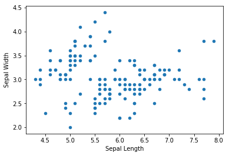

```python
df.plot('Sepal Length', 'Sepal Width', kind="scatter")
```

[output not shown]

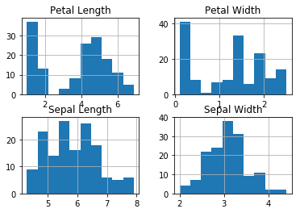

```python
df.hist()
```

[output not shown]

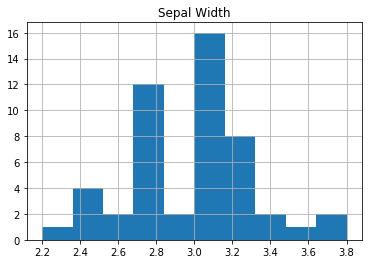

```python
df[df['Species'] == 'virginica'].hist(column=['Sepal Width'])
```

## Exercises

Using the `chipotle.tsv` file from Canvas, answer the following questions. (HINT: What convenience method works on `.tsv`s?)

1. What is the number of observations in this dataset?
   - HINT: (1) and (2) can be answered with the same DataFrame attribute!
2. What is the number of columns in the dataset?
3. What are the names of all the columns of this dataset?
4. What was the most ordered item?
   - HINT: Consider a groupby with an aggregation!
   - HINT: You will need to add up the `quantity` field across items of the same `item_name` and look at the results. There is an aggregation method called `sum()`.
5. How many times was a Veggie Salad Bowl ordered?

# Matplotlib

# Tour de Python Level 2 ○○○●

- basic `Matplotlib`
- a realistic example

```python
import matplotlib.pyplot as plt
```

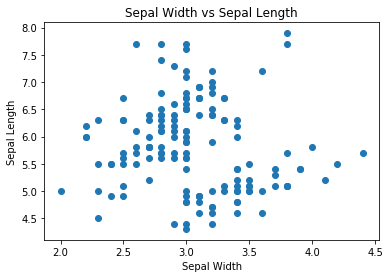

```python
plt.scatter(df['Sepal Width'], df['Sepal Length'])
plt.xlabel('Sepal Width')
plt.ylabel('Sepal Length')
plt.title('Sepal Width vs Sepal Length')
plt.show()
```

## A more realistic example

Take a look at the file `"gdp_time_series"` in your terminal with `cat`. You'll notice it's not so well formatted...

```python
# first, our container list
data_list_of_lists = []

# now open our file
f = open("gdp_time_series", "r")
# f that is my file "gdp_time_series" on disk
# iterate through each row after row 3; if you look at the data you'll see there's
# non-data in the first 3 lines
for row in f.readlines()[3:]: # use slice notation to skip the first 3 lines
    # split on arbitrary amount of whitespace
    current_row = row.split()
    # row.split is going to cause each row to turn into a list of strings
    # i.e. ['1950','0.02',...]

    # now add that list to our container list
    data_list_of_lists.append(current_row)
f.close()

# at the end of this for loop, in general, the data will look like:
# [['YEAR','AUSTRIA','CANADA'....],['1950','0.02'..]]
#
# now that we have a bunch of data in our list of lists, instantiate a DataFrame directly
# the first list in our list of lists is the header column
# the rest are our actual data
# so we slice the list of lists when we specify the data and the columns
df = pd.DataFrame(data=data_list_of_lists[1:],columns=data_list_of_lists[0])
```

```python
df.head()
```

|  | YEAR | AUSTRIA | CANADA | FRANCE | GERMANY | GREECE | ITALY | SWEDEN | UK | USA |
| --- | --- | --- | --- | --- | --- | --- | --- | --- | --- | --- |
| 0 | 1950 | 0.027523 | 3.651109 | 10.652861 | 5.725433 | 18.423605 | 0.799001 | 17.072701 | 1.033571 | 4.470303 |
| 1 | 1951 | 0.029406 | 3.734242 | 11.186672 | 6.256754 | 19.86624 | 0.829484 | 17.445339 | 1.060015 | 4.734335 |
| 2 | 1952 | 0.029357 | 3.932222 | 11.480235 | 6.70308 | 19.750938 | 0.859817 | 17.011088 | 1.104598 | 4.826502 |
| 3 | 1953 | 0.030603 | 4.019939 | 11.688318 | 7.256435 | 22.217731 | 0.916962 | 18.063728 | 1.152221 | 4.981746 |
| 4 | 1954 | 0.033678 | 3.860731 | 12.092329 | 7.72644 | 22.690231 | 0.942153 | 19.031748 | 1.191948 | 4.79081 |

```python
df.describe()
```

|  | YEAR | AUSTRIA | CANADA | FRANCE | GERMANY | GREECE | ITALY | SWEDEN | UK | USA |
| --- | --- | --- | --- | --- | --- | --- | --- | --- | --- | --- |
| count | 34 | 34 | 34 | 34 | 34 | 34 | 34 | 34 | 34 | 34 |
| unique | 34 | 34 | 34 | 34 | 34 | 34 | 34 | 34 | 33 | 33 |
| top | 1983 | 0.06178 | 6.062678 | 13.194351 | 15.720841 | 77.985801 | 2.825328 | 34.391346 | 1.355527 | 5.160474 |
| freq | 1 | 1 | 1 | 1 | 1 | 1 | 1 | 1 | 2 | 2 |

```python
df.dtypes
```

```
YEAR       object
AUSTRIA    object
CANADA     object
FRANCE     object
GERMANY    object
GREECE     object
ITALY      object
SWEDEN     object
UK         object
USA        object
dtype: object
```

```python
# we sent it all the data as strings, but we actually want to be able to do math on them
# so let's set the dtype of the entire dataframe as float
# here we overwrite 'df'
df = pd.DataFrame(data=data_list_of_lists[1:], columns=data_list_of_lists[0], dtype=float)
```

```python
df.dtypes
```

```
YEAR       float64
AUSTRIA    float64
CANADA     float64
FRANCE     float64
GERMANY    float64
GREECE     float64
ITALY      float64
SWEDEN     float64
UK         float64
USA        float64
dtype: object
```

```python
df.describe()
```

|  | YEAR | AUSTRIA | CANADA | FRANCE | GERMANY | GREECE | ITALY | SWEDEN | UK | USA |
| --- | --- | --- | --- | --- | --- | --- | --- | --- | --- | --- |
| count | 34.000000 | 34.000000 | 34.000000 | 34.000000 | 34.000000 | 34.000000 | 34.000000 | 34.000000 | 34.000000 | 34.000000 |
| mean | 1966.500000 | 0.065533 | 5.817088 | 20.957515 | 13.428460 | 50.932949 | 1.757668 | 28.073149 | 1.576265 | 6.241882 |
| std | 9.958246 | 0.025962 | 1.611434 | 7.369126 | 4.476840 | 24.196637 | 0.649375 | 7.221651 | 0.325664 | 1.227840 |
| min | 1950.000000 | 0.027523 | 3.651109 | 10.652861 | 5.725433 | 18.423605 | 0.799001 | 17.011088 | 1.033571 | 4.470303 |
| 25% | 1958.250000 | 0.043910 | 4.369293 | 14.160714 | 9.814249 | 28.701115 | 1.141946 | 20.886017 | 1.284349 | 5.080982 |
| 50% | 1966.500000 | 0.061104 | 5.578620 | 20.049311 | 12.990514 | 46.669707 | 1.720711 | 28.657428 | 1.558952 | 6.206709 |
| 75% | 1974.750000 | 0.087410 | 7.371888 | 27.614323 | 16.959558 | 74.144169 | 2.340225 | 34.850870 | 1.884099 | 7.327845 |
| max | 1983.000000 | 0.107894 | 8.382785 | 32.095989 | 19.985983 | 85.949501 | 2.825328 | 38.665154 | 2.079010 | 8.164851 |

```python
df = df.astype({"YEAR": object})
```

```python
df.head()
```

|  | YEAR | AUSTRIA | CANADA | FRANCE | GERMANY | GREECE | ITALY | SWEDEN | UK | USA |
| --- | --- | --- | --- | --- | --- | --- | --- | --- | --- | --- |
| 0 | 1950 | 0.027523 | 3.651109 | 10.652861 | 5.725433 | 18.423605 | 0.799001 | 17.072701 | 1.033571 | 4.470303 |
| 1 | 1951 | 0.029406 | 3.734242 | 11.186672 | 6.256754 | 19.866240 | 0.829484 | 17.445339 | 1.060015 | 4.734335 |
| 2 | 1952 | 0.029357 | 3.932222 | 11.480235 | 6.703080 | 19.750938 | 0.859817 | 17.011088 | 1.104598 | 4.826502 |
| 3 | 1953 | 0.030603 | 4.019939 | 11.688318 | 7.256435 | 22.217731 | 0.916962 | 18.063728 | 1.152221 | 4.981746 |
| 4 | 1954 | 0.033678 | 3.860731 | 12.092329 | 7.726440 | 22.690231 | 0.942153 | 19.031748 | 1.191948 | 4.790810 |

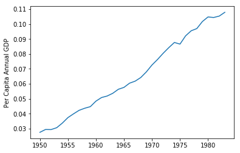

```python
plt.plot(df['YEAR'],df['AUSTRIA'])
plt.ylabel('Per Capita Annual GDP')
plt.show()
```